# Tutorial: Central Posterior Envelopes (CPEs) for Functional Components in Bayesian Longitudinal Functional Principal Component (B-LFPCA) Model

### Functional Eigenfunctions

```r
contour_case1_phi1_mbd <- CPEcontour(post_samples = posterior_summaries,
                                     type = "func_eigen",
                                     jork = 1,
                                     CPE = "MBD",
                                     alpha_cont = seq(0.05, 0.95, by = 0.10),
                                     sort = t,
                                     title = TeX(r"((a) Case 1, MBD-CPEs)"),
                                     xlab = "Time (t)")

contour_case1_phi1_mvd <- CPEcontour(post_samples = posterior_summaries,
                                     type = "func_eigen",
                                     jork = 1,
                                     CPE = "Marginal MVD",
                                     alpha_cont = seq(0.05, 0.95, by = 0.10),
                                     sort = t,
                                     title = TeX(r"((b) Case 1, MVD-CPEs)"),
                                     xlab = "Time (t)")

contour_case1_phi1_kmvd <- CPEcontour(post_samples = posterior_summaries,
                                      type = "func_eigen",
                                      jork = 1,
                                      CPE = "Kernel MVD",
                                      alpha_cont = seq(0.05, 0.95, by = 0.10),
                                      sort = t,
                                      title = TeX(r"((c) Case 1, Kernel MVD-CPEs)"),
                                      xlab = "Time (t)")

contour_case1_phi2_mbd <- CPEcontour(post_samples = posterior_summaries,
                                     type = "func_eigen",
                                     jork = 2,
                                     CPE = "MBD",
                                     alpha_cont = seq(0.05, 0.95, by = 0.10),
                                     sort = t,
                                     title = TeX(r"((a) Case 1, MBD-CPEs)"),
                                     xlab = "Time (t)")

contour_case1_phi2_mvd <- CPEcontour(post_samples = posterior_summaries,
                                     type = "func_eigen",
                                     jork = 2,
                                     CPE = "Marginal MVD",
                                     alpha_cont = seq(0.05, 0.95, by = 0.10),
                                     sort = t,
                                     title = TeX(r"((b) Case 1, MVD-CPEs)"),
                                     xlab = "Time (t)")

contour_case1_phi2_kmvd <- CPEcontour(post_samples = posterior_summaries,
                                      type = "func_eigen",
                                      jork = 2,
                                      CPE = "Kernel MVD",
                                      alpha_cont = seq(0.05, 0.95, by = 0.10),
                                      sort = t,
                                      title = TeX(r"((c) Case 1, Kernel MVD-CPEs)"),
                                      xlab = "Time (t)")
```

### Visualization of MVD-CPE contours of the mean function

Plotted at different $\alpha$ levels marked by varying colors, overlaid with $C = 6000$ posterior estimates in gray. To visualize the MVD-CPE contours, the CPEs of the mean function are displayed in functional time (t) at fixed slices of longitudinal time $s \in \mathcal{S}$ (i.e. ($\mu(t|s)$) for the $n_s = 20$ total time points. The solid black line represents the MVD median, denoted by $\widetilde{m}\{\mu(s, t)\}$, and the solid red line represents the true function.

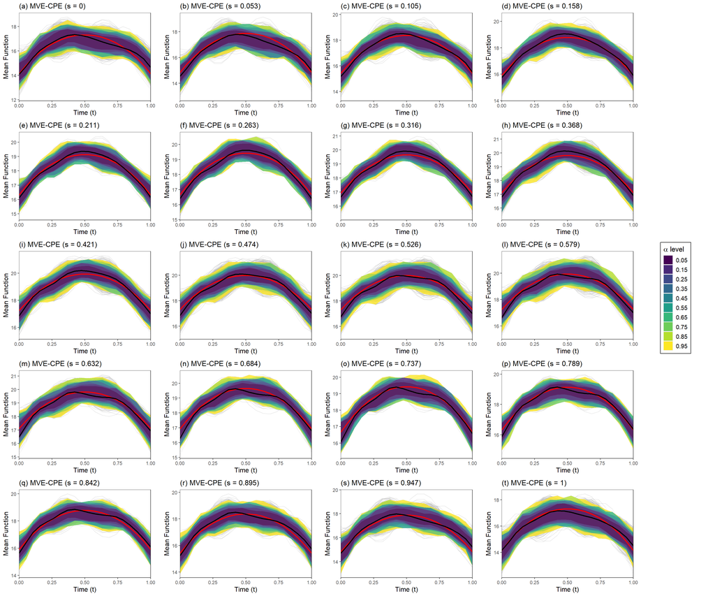

```r
muCPEcontour(post_samples = posterior_summaries,        # Outputs from FDpostSumms_BLFPCA_postSumms.R
               alpha_cont = seq(0.05, 0.95, by = 0.10), # Vector of alpha values for the CPE contours, a vector of real                                                            numbers
                        s = seq(0, 1, length = 20),     # Vector of longitudinal time points to be plotted, a                                                                      vector of real numbers
                        t = seq(0, 1, length = 20)      # Vector of functional time points to be plotted, a                                                                        vector of real numbers
)
```